# COVID Support Loss Analytic Code

# Study Overview

This study investigates loss of mental, behavioral, and/or emotional support in the midst of the COVID-19 pandemic among undergraduate students at a large university. The goal of this study is to gather evidence on the extent of this loss and whether it differs by individual characteristics. Specifically, we seek to answer the following questions:

1. What is the extent of loss of support during the COVID-19 pandemic among members of a large university community?
2. Does loss of support differ by (a) sociodemographic factors or (b) levels of depression and anxiety symptomatology, including suicidal ideation?

This is an exploratory study and we do not have specific hypotheses regarding the extent of support loss, or whether/how it differs across the above conditions.

Analyses are limited to complete cases only. This drops 4 of 419 cases.

# Sample Description

Categorical variables (report n, percent)

```
## # A tibble: 15 x 4
## # Groups:   name [6]
##    name           value                  n pct
##    <chr>          <chr>              <int> <chr>
##  1 ethnicity      Asian non-Hispanic   107 25.78%
##  2 ethnicity      Black non-Hispanic    20 4.82%
##  3 ethnicity      Hispanic              68 16.39%
##  4 ethnicity      Multi non-Hispanic    23 5.54%
##  5 ethnicity      White non-Hispanic   197 47.47%
##  6 genderMinority FALSE                401 96.63%
##  7 genderMinority TRUE                  14 3.37%
##  8 sex            Female               324 78.07%
##  9 sex            Male                  91 21.93%
## 10 sexualMinority FALSE                293 70.60%
## 11 sexualMinority TRUE                 122 29.40%
## 12 SI             FALSE                302 72.77%
## 13 SI             TRUE                 113 27.23%
## 14 supportLoss    FALSE                157 37.83%
## 15 supportLoss    TRUE                 258 62.17%
```

Continuous variables (report mean, sd)

```
## # A tibble: 2 x 6
##   name   mean    sd `>= 10` `>= 15` `>= 20`
##   <chr> <dbl> <dbl>   <dbl>   <dbl>   <dbl>
## 1 GAD7   10.3  5.98   0.520   0.282  0.0699
## 2 PHQ    12.1  6.70   0.607   0.337  0.173
```

# Support loss by COVID impacts

```
## # A tibble: 14 x 5
##    impactType          impactPresence.m impactPresence.n     n impactPresence
##    <chr>                          <dbl>            <int> <int> <chr>
##  1 impact.childcare             0.00964                4   415 0.96% (4 of 415)
##  2 impact.edRemote              0.978                406   415 97.83% (406 of 4~
##  3 impact.extraHours            0.0843                35   415 8.43% (35 of 415)
##  4 impact.hadToWork             0.0771                32   415 7.71% (32 of 415)
##  5 impact.illnessOfCo~          0.152                 63   415 15.18% (63 of 41~
##  6 impact.jobLoss               0.422                175   415 42.17% (175 of 4~
##  7 impact.jobRemote             0.198                 82   415 19.76% (82 of 41~
##  8 impact.livingSitua~          0.422                175   415 42.17% (175 of 4~
##  9 impact.mandQuarant~          0.0940                39   415 9.40% (39 of 415)
## 10 impact.other                 0.0675                28   415 6.75% (28 of 415)
## 11 impact.relativesMo~          0.205                 85   415 20.48% (85 of 41~
## 12 impact.reunitedWit~          0.308                128   415 30.84% (128 of 4~
## 13 impact.selfQuarant~          0.424                176   415 42.41% (176 of 4~
## 14 impact.shelterInPl~          0.684                284   415 68.43% (284 of 4~
```

```
## # A tibble: 14 x 3
##    `Impact Type`    `Support Loss`      `No Loss`
##    <chr>            <chr>               <chr>
##  1 childcare        0.78% (2 of 258)    1.27% (2 of 157)
##  2 edRemote         97.29% (251 of 258) 98.73% (155 of 157)
##  3 extraHours       8.14% (21 of 258)   8.92% (14 of 157)
##  4 hadToWork        9.69% (25 of 258)   4.46% (7 of 157)
##  5 illnessOfContact 17.83% (46 of 258)  10.83% (17 of 157)
##  6 jobLoss          45.74% (118 of 258) 36.31% (57 of 157)
##  7 jobRemote        19.38% (50 of 258)  20.38% (32 of 157)
##  8 livingSituation  48.45% (125 of 258) 31.85% (50 of 157)
##  9 mandQuarantine   11.63% (30 of 258)  5.73% (9 of 157)
## 10 other            6.98% (18 of 258)   6.37% (10 of 157)
## 11 relativesMovedIn 23.64% (61 of 258)  15.29% (24 of 157)
## 12 reunitedWithFam  31.78% (82 of 258)  29.30% (46 of 157)
## 13 selfQuarantine   43.41% (112 of 258) 40.76% (64 of 157)
## 14 shelterInPlace   71.32% (184 of 258) 63.69% (100 of 157)
```

# Internal consistency

Internal consistency for GAD7

|  | raw_alpha | std.alpha | G6(smc) | average_r | S/N | ase | mean | sd | median_r |
| --- | --- | --- | --- | --- | --- | --- | --- | --- | --- |
|  | 0.91 | 0.91 | 0.91 | 0.59 | 10.13 | 0.01 | 2.47 | 0.85 | 0.57 |

Internal consistency for PHQ

|  | raw_alpha | std.alpha | G6(smc) | average_r | S/N | ase | mean | sd | median_r |
| --- | --- | --- | --- | --- | --- | --- | --- | --- | --- |
|  | 0.89 | 0.89 | 0.89 | 0.48 | 8.23 | 0.01 | 2.35 | 0.74 | 0.5 |

# Main analysis

```
## [1] "Expected values for the Chi-square test of supportLoss, sex"
##
##           Female     Male
##   FALSE 122.5735 34.42651
##   TRUE  201.4265 56.57349
## [1] "Expected values for the Chi-square test of supportLoss, ethnicity"
##
##         Asian non-Hispanic Black non-Hispanic Hispanic Multi non-Hispanic
##   FALSE           40.47952           7.566265  25.7253           8.701205
##   TRUE            66.52048          12.433735  42.2747          14.298795
##
##         White non-Hispanic
##   FALSE           74.52771
##   TRUE           122.47229
## [1] "Expected values for the Chi-square test of supportLoss, genderMinority"
##
##            FALSE     TRUE
##   FALSE 151.7036 5.296386
##   TRUE  249.2964 8.703614
## [1] "Expected values for the Chi-square test of supportLoss, sexualMinority"
##
##            FALSE     TRUE
##   FALSE 110.8458 46.15422
##   TRUE  182.1542 75.84578
## [1] "Expected values for the Chi-square test of supportLoss, SI"
##
##            FALSE    TRUE
##   FALSE 114.2506 42.7494
##   TRUE  187.7494 70.2506
```

| group | lostSupport | statistic | p |
| --- | --- | --- | --- |
| Full sample | 62.2% (n=415) |  |  |
| sex |  | X-squared(df=1) = 1.54 | p = 0.25 |
| Female | 63.9% (n=324) |  |  |
| Male | 56.0% (n=91) |  |  |
| ethnicity |  | X-squared(df=4) = 9.79 | p = 0.062 |
| White non-Hispanic | 57.4% (n=197) |  |  |
| Asian non-Hispanic | 58.9% (n=107) |  |  |
| Hispanic | 75.0% (n=68) |  |  |
| Multi non-Hispanic | 78.3% (n=23) |  |  |
| Black non-Hispanic | 65.0% (n=20) |  |  |
| genderMinority |  | X-squared(df=1) = 0 | p = 1 |
| FALSE | 62.1% (n=401) |  |  |
| TRUE | 64.3% (n=14) |  |  |
| sexualMinority |  | X-squared(df=1) = 6.704 | p = 0.017 |
| FALSE | 58.0% (n=293) |  |  |
| TRUE | 72.1% (n=122) |  |  |
| GAD7 |  | t(df=321.3) = 4.716 | p = 0 |
| PHQ |  | t(df=359.1) = 6.287 | p = 0 |
| SI |  | X-squared(df=1) = 17.22 | p = 0 |
| FALSE | 56.0% (n=302) |  |  |
| TRUE | 78.8% (n=113) |  |  |

A quick table to aid in the interpretation of above t-tests

| supportLoss | n | GAD7 | PHQ |
| --- | --- | --- | --- |
| FALSE | 157 | 8.54 (5.94) | 9.64 (5.96) |
| TRUE | 258 | 11.34 (5.76) | 13.62 (6.7) |

And a plot to this effect

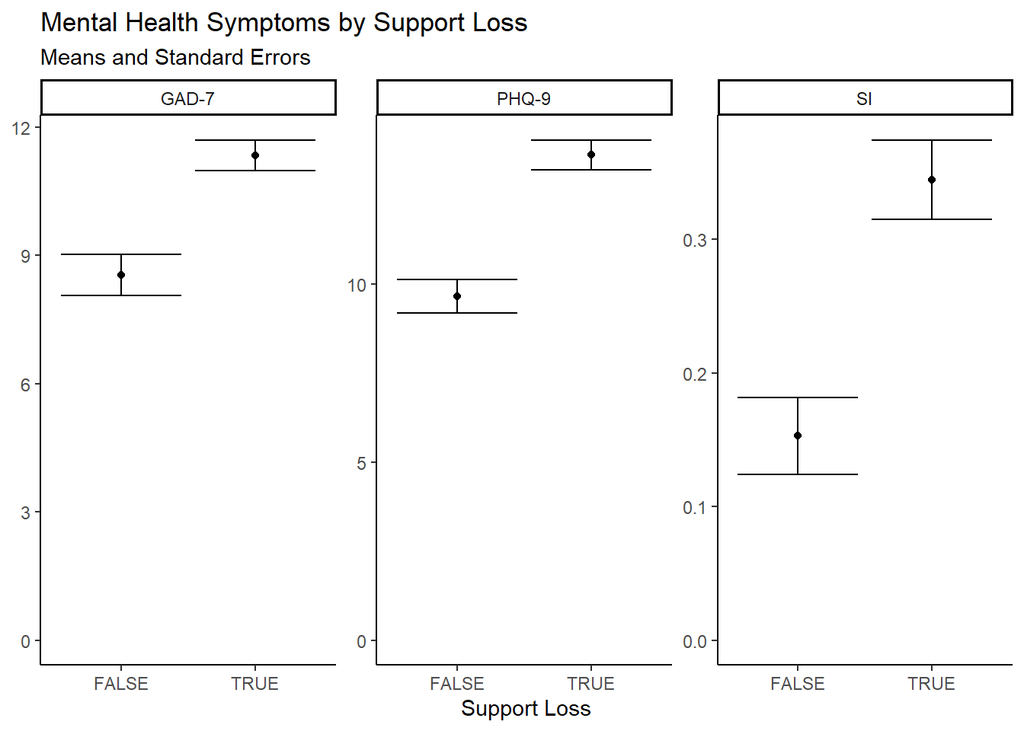

Another pair of tables on the SI - support loss relationship

```
## # A tibble: 4 x 4
## # Groups:   SI [2]
##   SI    supportLoss     n pct
##   <lgl> <lgl>       <int> <chr>
## 1 FALSE FALSE         133 44%
## 2 FALSE TRUE          169 56%
## 3 TRUE  FALSE          24 21%
## 4 TRUE  TRUE           89 79%
```

```
## # A tibble: 4 x 4
## # Groups:   supportLoss [2]
##   supportLoss SI        n pct
##   <lgl>       <lgl> <int> <chr>
## 1 FALSE       FALSE   133 85%
## 2 FALSE       TRUE     24 15%
## 3 TRUE        FALSE   169 66%
## 4 TRUE        TRUE     89 34%
```